# Lecture 19 Fixed Effects

Nick Huntington-Klein

March 8, 2019

## Recap

- Last time we talked about how controlling is a common way of blocking back doors to identify an effect
- We can control for a variable `W` by using our method of using `W` to explain our other variables, then take the residuals
- Another form of controlling is using a sample that has only observations with similar values of `W`
- Some variables you want to be careful NOT to control for - you don’t want to close front doors, or open back doors by controlling for colliders

## Today

- Today we’ll be starting on our path for the rest of the class, where we’ll be talking about standard *methods* for performing causal inference
- Different ways of getting identification once we have a diagram!
- Our goal here will be to understand these methods *conceptually*
- We won’t necessarily be doing best-statistical-practices for these. You’ll learn those in later classes, and best-practices change over time anyway
- Our goal is to *understand* these methods and be able to apply a straightforward version of them, not to *publish a research paper*

## Today

- In particular we’ll be talking about a method that is commonly used to identify causal effects, called fixed effects
- We’ll be discussing the *kind* of causal diagram that fixed effects can identify
- All of the methods we’ll be discussing are like this - they’ll only apply to particular diagrams
- And so knowing our diagrams will be key to knowing when to use a given method

## The Problem

- One problem we ran into last time is that we can’t really control for things if we can’t measure them
- And there are lots of things we can’t measure or don’t have data for!
- So what can we do?

## The Solution

- If we observe each person/firm/country *multiple times*, then we can forget about controlling for the actual back-door variable we’re interested in
- And just control for *person/firm/country identity* instead!
- This will control for EVERYTHING unique to that individual, whether we can measure it or not!

## In Practice

- Let’s do this on the data from the “gapminder” package
- This data tracks life expectancy and GDP per capita in many countries over time

```r
library(gapminder)
data(gapminder)
cor(gapminder$lifeExp,log(gapminder$gdpPercap))
```

```
## [1] 0.8076179
```

```r
gapminder <- gapminder %>% group_by(country) %>%
  mutate(lifeExp.r = lifeExp - mean(lifeExp),
         logGDP.r = log(gdpPercap) - mean(log(gdpPercap))) %>% ungroup()
cor(gapminder$lifeExp.r,gapminder$logGDP.r)
```

```
## [1] 0.6404051
```

## So What?

- This isn’t any different, mechanically, from any other time we’ve controlled for something
- So what’s different here?
- Let’s think about what we’re doing conceptually

## What’s the Diagram?

- Why are we controlling for things in this gapminder analysis?
- Because there are LOTS of things that might be back doors between GDP per capita and life expectancy
- War, disease, political institutions, trade relationships, health of the population, economic institutions…

## What’s the Diagram?

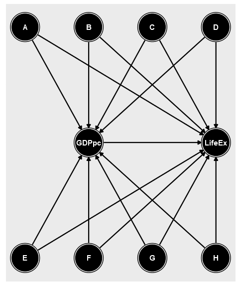

## What’s the Diagram?

- There’s no way we can identify this
- The list of back doors is very long
- And likely includes some things we can’t measure!

## What’s the Diagram?

- HOWEVER! If we think that these things are likely to be constant within country…
- Then we don’t really have a big long list of back doors, we just have one: “country”

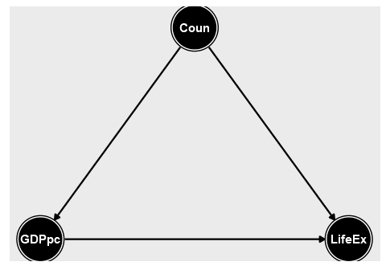

## What We Get

- So what we get out of this is that we can identify our effect even if some of our back doors include variables that we can’t actually measure
- When we do this, we’re basically comparing countries *to themselves* at different time periods!
- Pretty good way to do an apples-to-apples comparison!

## Graphically

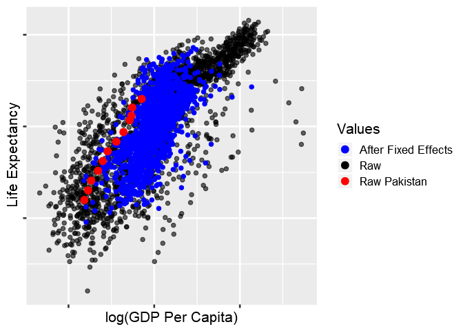

## Graphically

- The post-fixed-effects dots are basically a bunch of “Raw Country X” pasted together.
- Imagine taking “Raw Pakistan” and moving it to the center, then taking “Raw Britain” and moving it to the center, etc.
- Ignoring the baseline differences between Pakistan, Britain, China, etc., in their GDP per capita and life expectancy, and just looking within each country.
- We are ignoring all differences *between* countries (since that way back doors lie!) and looking only at differences *within* countries.
- Fixed Effects is sometimes also referred to as the “within” estimator

## In Action

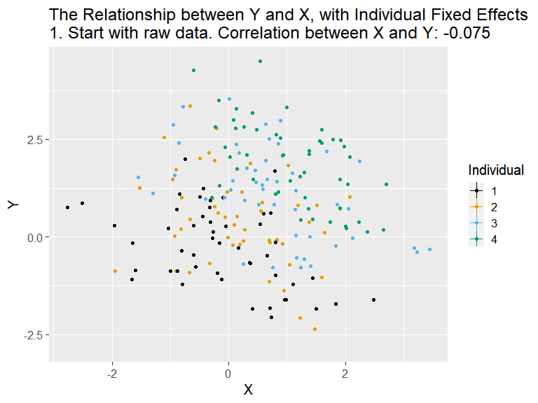

## Notably

- This does assume, of course, that all those back door variables CAN be described by country
- In other words, that these back doors operate by things that are *fixed* within country
- If something is a back door and changes over time in that country, fixed effects won’t help!

## Varying Over Time

- For example, earlier we mentioned war… that’s not fixed within country! A given country is at war sometimes and not other times.

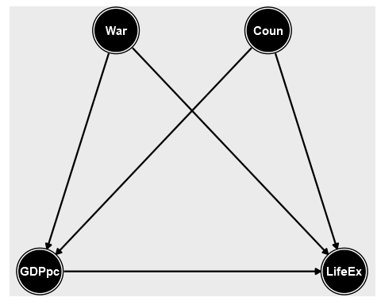

## Varying Over Time

- Of course, in this case, we could control for War as well and be good!
- Time-varying things doesn’t mean that fixed effects doesn’t work, it just means you need to control for that stuff too
- It always comes down to thinking carefully about your diagram
- Fixed effects mainly works as a convenient way of combining together lots of different constant-within-country back doors into something that lets us identify the model even if we can’t measure them all

## Example: Sentencing

- What effect do sentencing reforms have on crime?
- One purpose of punishment for crime is to deter crime
- If sentences are more clear and less risky, that may reduce a deterrent to crime and so increase crime
- Marvell & Moody study this using data on reforms in US states from 1969-1989

## Example: Sentencing

- I’ve omitted code reading in the data
- But in our data we have multiple observations per state

```r
head(mmdata)
```

```
## # A tibble: 6 x 6
##   state   year assault robbery pop1000 sentreform
##   <chr>  <dbl>   <dbl>   <dbl>   <dbl>      <dbl>
## 1 "ALA "    70    7413    1731    3450          0
## 2 "ALA "    71    7645    2005    3497          0
## 3 "ALA "    72    7431    2407    3540          0
## 4 "ALA "    73    8362    2809    3581          0
## 5 "ALA "    74    8429    3562    3628          0
## 6 "ALA "    75    8440    4446    3681          0
```

```r
mmdata <- mmdata %>% mutate(assaultper1000 = assault/pop1000,
         robberyper1000 = robbery/pop1000)
```

## Fixed Effects

- We can see how robbery rates evolve in each state over time as states implement reform

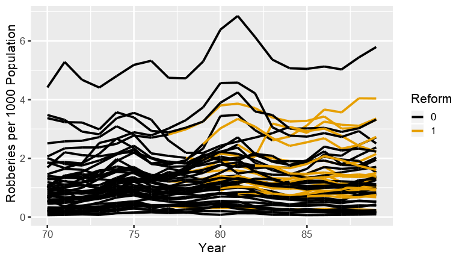

## Fixed Effects

- You can tell that states are more or less likely to implement reform in a way that’s correlated with the level of robbery they already had
- So SOMETHING about the state is driving both the level of robberies AND the decision to implement reform
- Who knows what!
- Our diagram has `reform -> robberies` and `reform <- state -> robberies`, which is something we can address with fixed effects.

## Fixed Effects

```r
cor(mmdata$sentreform,mmdata$robberyper1000)
```

```
## [1] 0.1351003
```

```r
mmdata <- mmdata %>% group_by(state) %>%
  mutate(reform.m = sentreform-mean(sentreform),
         robbery.m = robberyper1000-mean(robberyper1000))
cor(mmdata$reform.m,mmdata$robbery.m)
```

```
## [1] 0.2482301
```

## Example

- The numbers were different
- The 0.135 included the fact that different kinds of states tend to institute reform
- The 0.248 doesn’t!
- Looks like the deterrent effect was real! Although important to consider if there might be time-varying back doors too, we don’t account for those in our analysis
- What things might change within state over time that would be related to robberies and to sentencing reform?

## Practice

- We want to know the effect of your `teacher` on the `test score`s of high school students
- Some potential back doors might go through: `parents' intelligence`, `age`, `demographics`, `school`, `last year's teacher`
- Draw a diagram including all these variables, plus maybe some unobservables where appropriate
- If you used fixed effects for students, what back doors would still be open?

## Practice Answers

- Fixed effects would close your back doors for `parents' intelligence`, `demographics`, and `school`, but leave open `age` and `last year's teacher`